# ESDSWRF Oat-Pea Polyculture Manuscript Analysis

#### Plot

```r
#
annotate_df = emeans %>%
  as.data.frame
annotate_df$.group %<>% trimws()

grpY = group_Y(resp2, grp, data=dd)
annotate_df %<>% merge(grpY, all.x=TRUE)

pltdf = c('CROP', 'PLANTING', 'PREDATION') %>%
  dd[, .]
```

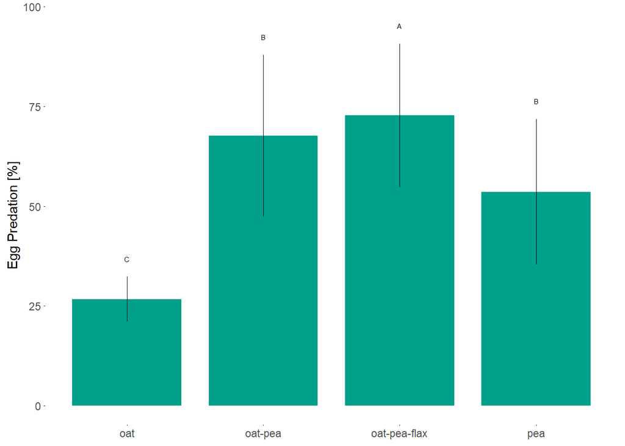

```r
dodger = position_dodge(width=0.8)

plt = ggplot(pltdf,
             aes(x=CROP,
                 y=100*PREDATION)) +
  # scale_fill_manual(values=colors[3:4]) +
  stat_summary(fun=mean,
               geom='bar',
               position=dodger,
               width=0.8,
               fill=colors[2]) +
  stat_summary(fun.data=mean_se,
               geom='errorbar',
               width=0,
               position=dodger,
               linewidth=0.1) +
  geom_text(data=annotate_df,
            aes(x=CROP,
                y=Y*100,
                label=.group),
            inherit.aes=FALSE,
            size=2,
            position=dodger) +
  labs(x=NULL,
       y='Egg Predation [%]',
       fill=NULL)
plt %<>% gg_formatter

plt
```

```r
eggplt = plt
```

Values in the above graph are:

```r
get_mean_se(paste(resp2, pred, sep='~') %>%
              formula,
            data=df)
```

| CROP | PREDATION.MEAN | PREDATION.SE |
| --- | --- | --- |
| oat | 0.2670688 | 0.05607315 |
| oat-pea | 0.6764172 | 0.20255499 |
| oat-pea-flax | 0.7273645 | 0.18001982 |
| pea | 0.5361453 | 0.18239460 |

### Morphospecies Richness

```r
resp = 'BUGVAC_RICHNESS'
pred = 'CROP'
err = '(1|REP)'
dd = subset(df, PLANTING != 'late')


ff = paste(resp, '~', pred, '+', err) %>%
  formula

mod = glmer(ff, data=dd, family=poisson())
```

```
## boundary (singular) fit: see help('isSingular')
```

```r
av = Anova(mod)
av
```

|  | Chisq | Df | Pr(>Chisq) |
| --- | --- | --- | --- |
| CROP | 13.41116 | 3 | 0.003826782 |

```r
anova_table = make_anova_table(av, append_to=anova_table)
```

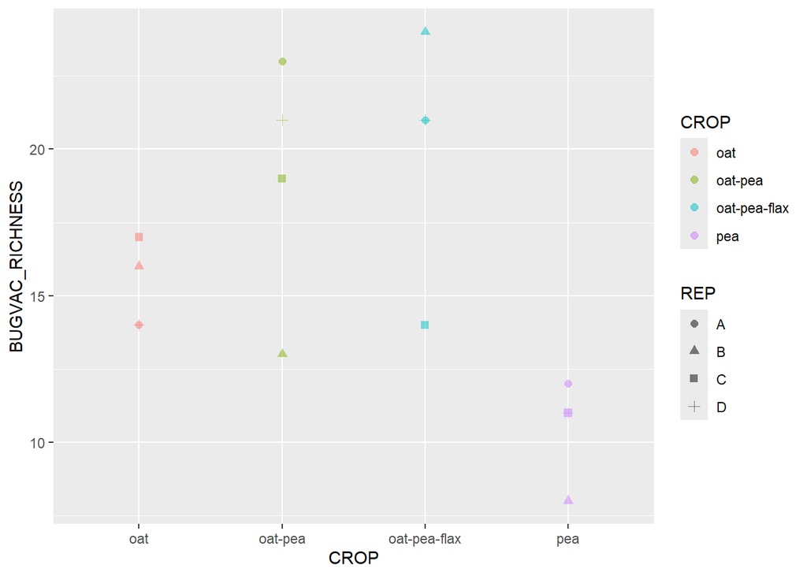

```r
ggplot(dd,
       aes(x=CROP,
           y=.data[[resp]],
           color=CROP,
           shape=REP)) +
  geom_point(alpha=0.5,
             size=2)
```

```r
emeans = emmeans(mod, ~CROP) %>%
  cld(Letters=LETTERS,
      reverse=TRUE,
      p.adjust='fdr',
      type='response')
emeans
```

|  | CROP | rate | SE | df | asymp.LCL | asymp.UCL | .group |
| --- | --- | --- | --- | --- | --- | --- | --- |
| 4 | oat-pea-flax | 20.00 | 2.236068 | Inf | 16.06434 | 24.89988 | A |
| 1 | oat-pea | 19.00 | 2.179449 | Inf | 15.17449 | 23.78993 | A |
| 2 | oat | 15.25 | 1.952562 | Inf | 11.86546 | 19.59995 | AB |
| 3 | pea | 10.50 | 1.620185 | Inf | 7.75972 | 14.20799 | B |

#### Plot

```r
grp = 'CROP'
annotate_df = emeans %>%
  as.data.frame
annotate_df$.group %<>% trimws()

grpY = group_Y(resp, grp, data=dd)
annotate_df %<>% merge(grpY, all.x=TRUE)

pltdf = c('CROP', 'PLANTING', 'BUGVAC_RICHNESS') %>%
  dd[, .]
```

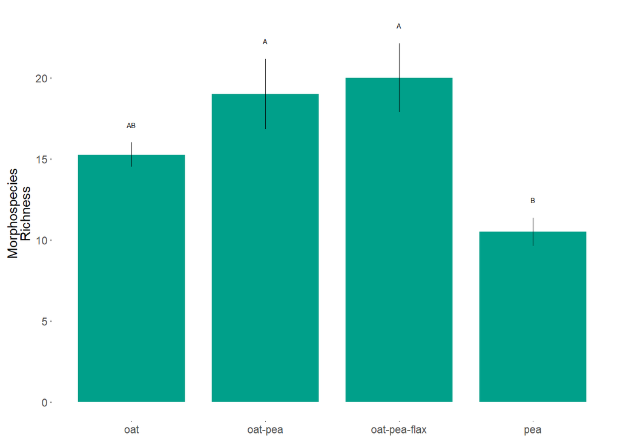

```r
dodger = position_dodge(width=0.8)

plt = ggplot(pltdf,
             aes(x=CROP,
                 y=.data[[resp]])) +
  # scale_fill_manual(values=colors[3:4]) +
  stat_summary(fun=mean,
               geom='bar',
               position=dodger,
               width=0.8,
               fill=colors[2]) +
  stat_summary(fun.data=mean_se,
               geom='errorbar',
               width=0,
               position=dodger,
               linewidth=0.1) +
  geom_text(data=annotate_df,
            aes(x=CROP,
                y=Y,
                label=.group),
            inherit.aes=FALSE,
            size=2,
            position=dodger) +
  labs(x=NULL,
       y='Morphospecies<br>Richness',
       fill=NULL)
plt %<>% gg_formatter

plt
```

```r
richplt = plt
```

## Arthropod abudnance

Richness was driven primarily by higher abundance.

```r
resp = 'BUGVAC_ABUNDANCE'
pred = 'CROP'
err = '(1|REP)'
dd = subset(df, PLANTING != 'late')


ff = paste(resp, '~', pred, '+', err) %>%
  formula

mod = glmer.nb(ff, data=dd)
av = Anova(mod)
av
```

|  | Chisq | Df | Pr(>Chisq) |
| --- | --- | --- | --- |
| CROP | 86.38912 | 3 | 1.306028e-18 |

```r
anova_table = make_anova_table(av, append_to=anova_table)
```

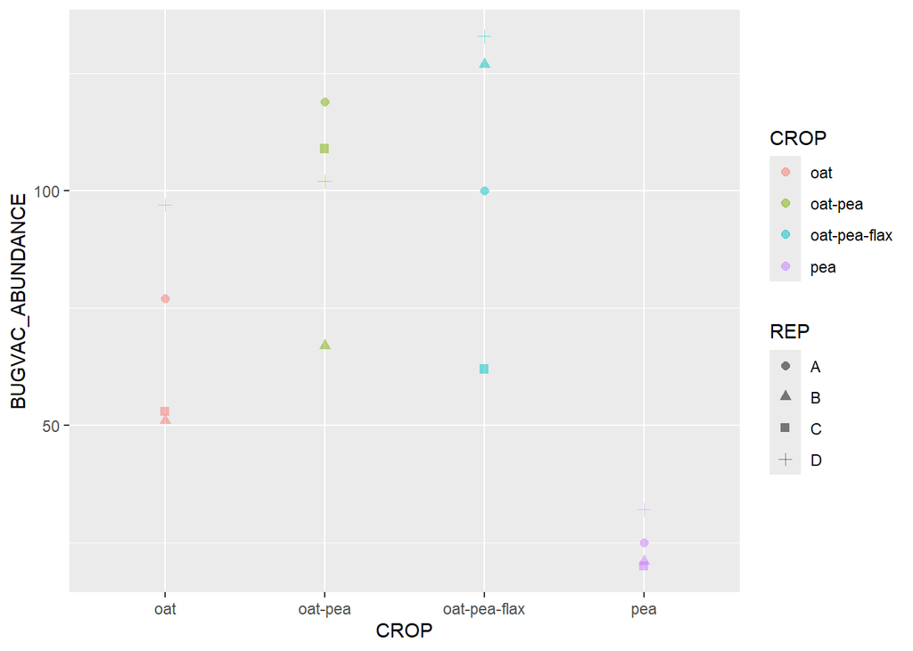

```r
ggplot(dd,
       aes(x=CROP,
           y=.data[[resp]],
           color=CROP,
           shape=REP)) +
  geom_point(alpha=0.5,
             size=2)
```

```r
emeans = emmeans(mod, ~CROP) %>%
  cld(Letters=LETTERS,
      reverse=TRUE,
      p.adjust='fdr',
      type='response')
emeans
```

|  | CROP | response | SE | df | asymp.LCL | asymp.UCL | .group |
| --- | --- | --- | --- | --- | --- | --- | --- |
| 4 | oat-pea-flax | 104.44470 | 12.595820 | Inf | 82.45808 | 132.29383 | A |
| 1 | oat-pea | 98.93367 | 11.974581 | Inf | 78.04008 | 125.42109 | AB |
| 2 | oat | 68.36869 | 8.595237 | Inf | 53.43738 | 87.47206 | B |
| 3 | pea | 24.25601 | 3.628042 | Inf | 18.09267 | 32.51891 | C |

But the mixed plots had higher abundance.

#### Plot

```r
grp = 'CROP'
annotate_df = emeans %>%
  as.data.frame
annotate_df$.group %<>% trimws()

grpY = group_Y(resp, grp, data=dd)
annotate_df %<>% merge(grpY, all.x=TRUE)

pltdf = c('CROP', 'PLANTING', resp) %>%
  dd[, .]
```

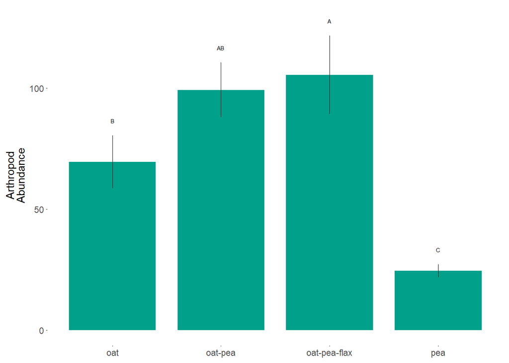

```r
dodger = position_dodge(width=0.8)

plt = ggplot(pltdf,
             aes(x=CROP,
                 y=.data[[resp]])) +
  stat_summary(fun=mean,
               geom='bar',
               position=dodger,
               width=0.8,
               fill=colors[2]) +
  stat_summary(fun.data=mean_se,
               geom='errorbar',
               width=0,
               position=dodger,
               linewidth=0.1) +
  geom_text(data=annotate_df,
            aes(x=CROP,
                y=Y,
                label=.group),
            inherit.aes=FALSE,
            size=2,
            position=dodger) +
  labs(x=NULL,
       y='Arthropod<br>Abundance',
       fill=NULL)
plt %<>% gg_formatter

plt
```

```r
abundplt = plt
```

### Richness with abundance

```r
resp = 'BUGVAC_RICHNESS'
pred = 'CROP + BUGVAC_ABUNDANCE'
err = '(1|REP)'
dd = subset(df, PLANTING != 'late')


ff = paste(resp, '~', pred, '+', err) %>%
  formula

mod = glmer(ff, data=dd, family=poisson())
```

```
## boundary (singular) fit: see help('isSingular')
```

```r
Anova(mod)
```

|  | Chisq | Df | Pr(>Chisq) |
| --- | --- | --- | --- |
| CROP | 0.4834721 | 3 | 0.92250722 |
| BUGVAC_ABUNDANCE | 2.8364475 | 1 | 0.09214774 |

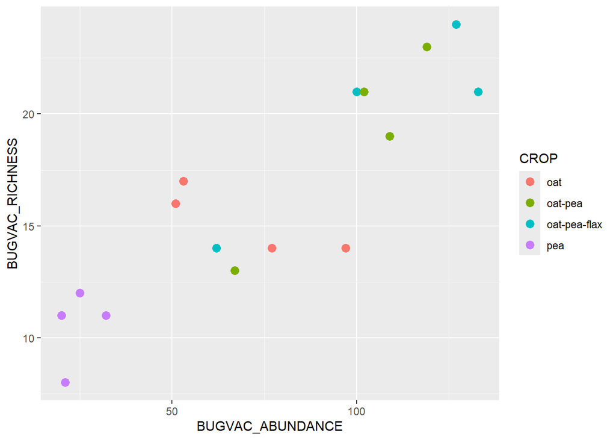

```r
ggplot(df,
       aes(x=BUGVAC_ABUNDANCE,
           y=BUGVAC_RICHNESS,
           color=CROP)) +
  geom_point(size=3)
```

## Weeds

log<sub>10</sub> transform to meet linear model assumptions.

```r
resp = 'log(WEED_BIOMASS_MATURITY+1, 10)'
resp1 = 'WEED_BIOMASS_MATURITY'
pred = 'CROP*PLANTING'
err = '(1|REP/PLANTING)'

ff = paste(resp, '~', pred, '+', err) %>%
  formula

mod = lmer(ff, data=df)
av = Anova(mod, test.statistic='F')
av
```

|  | F | Df | Df.res | Pr(>F) |
| --- | --- | --- | --- | --- |
| CROP | 2.5799897 | 3 | 15.00812 | 0.09218401 |
| PLANTING | 0.8186324 | 1 | 3.26772 | 0.42727177 |
| CROP:PLANTING | 0.5170670 | 2 | 15.00812 | 0.60651186 |

```r
anova_table = make_anova_table(av, append_to=anova_table)
```

Marginal effect - pea had slightly lower weed biomass, but not meaningfully so.

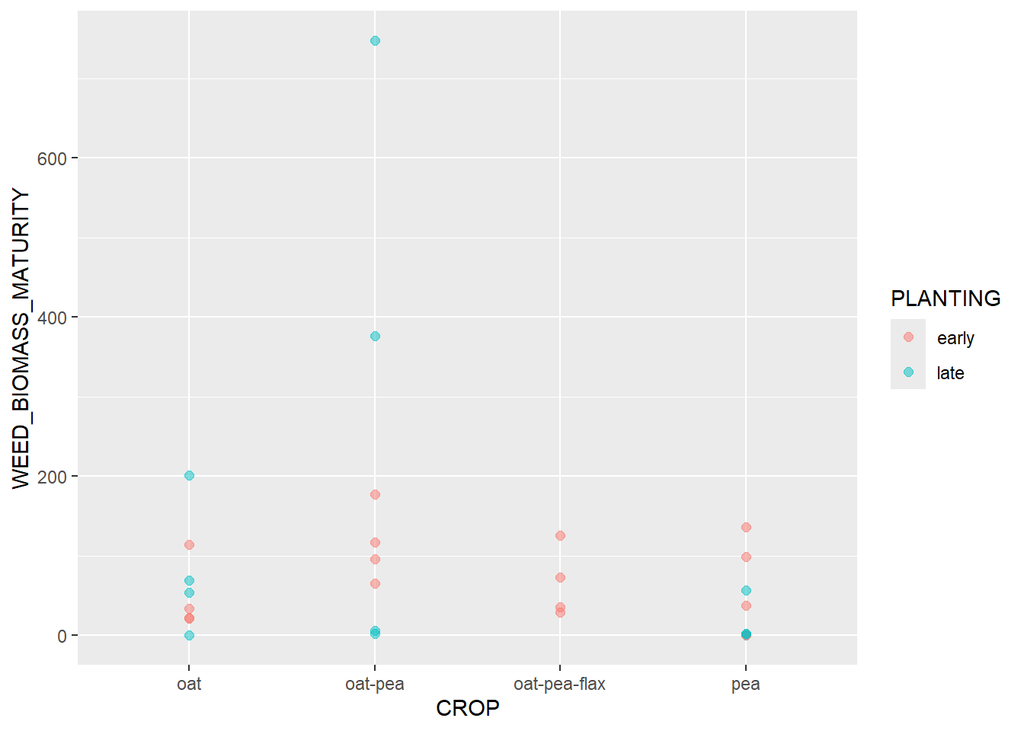

```r
ggplot(df,
       aes(x=CROP,
           y=.data[[resp1]],
           color=PLANTING)) +
  geom_point(alpha=0.5,
             size=2)
```

Any differences with oat-pea are strongly driven by an outlier.

```r
emeans = emmeans(mod, ~CROP|PLANTING) %>%
  cld(Letters=LETTERS,
      reverse=TRUE,
      p.adjust='fdr',
      type='response')
emeans
```

|  | CROP | PLANTING | response | SE | df | lower.CL | upper.CL | .group |
| --- | --- | --- | --- | --- | --- | --- | --- | --- |
| 4 | oat-pea | early | 7.644513 | 2.9522091 | 13.44148 | 3.3282932 | 17.558124 | A |
| 1 | oat-pea-flax | early | 5.769518 | 2.2281107 | 13.44148 | 2.5119514 | 13.251583 | A |
| 3 | oat | early | 4.866607 | 1.8794188 | 13.44148 | 2.1188394 | 11.177755 | A |
| 2 | pea | early | 4.187307 | 1.6170822 | 13.44148 | 1.8230835 | 9.617520 | A |
| 8 | oat-pea-flax | late | NA | NA | NA | NA | NA |  |
| 5 | oat-pea | late | 5.596170 | 2.1611661 | 13.44148 | 2.4364787 | 12.853434 | A |
| 6 | oat | late | 4.358142 | 1.6830561 | 13.44148 | 1.8974619 | 10.009897 | A |
| 7 | pea | late | 2.122327 | 0.8196144 | 13.44148 | 0.9240257 | 4.874618 | A |

But actually, pea is (slightly) lower - and did receive herbicide.

#### Plot

```r
grp = 'CROP'
annotate_df = emeans %>%
  as.data.frame
annotate_df$.group %<>% trimws()

pltdf = c('CROP', 'PLANTING', resp1) %>%
  df[, .]
late_flax = data.frame(CROP='oat-pea-flax' %>%
                 factor(levels=levels(df$CROP)),
               PLANTING='late' %>%
                 factor(levels=levels(df$PLANTING)),
               x=0) %>%
  set_names(names(pltdf))
pltdf %<>% rbind(late_flax)

pltdf$prettyplanting = pltdf$PLANTING %>%
  as.character %>%
  prettyplanting[.]
annotate_df$prettyplanting = annotate_df$PLANTING %>%
  as.character %>%
  prettyplanting[.]
```

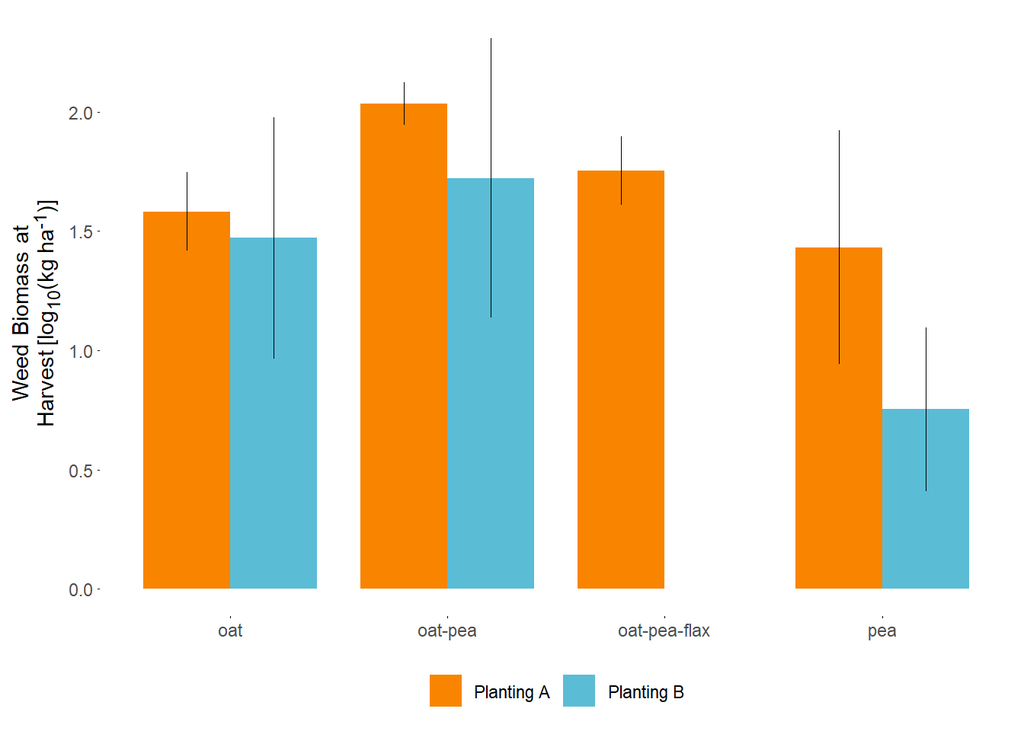

```r
dodger = position_dodge(width=0.8)

plt = ggplot(pltdf,
             aes(x=CROP,
                 y=log(WEED_BIOMASS_MATURITY+1, 10),
                 fill=prettyplanting)) +
  scale_fill_manual(values=colors[3:4]) +
  stat_summary(fun=mean,
               geom='bar',
               position=dodger,
               width=0.8) +
  stat_summary(fun.data=mean_se,
               geom='errorbar',
               width=0,
               position=dodger,
               linewidth=0.1) +
  labs(x=NULL,
       y='Weed Biomass at<br>Harvest [log<sub>10</sub>(kg ha<sup>-1</sup>)]',
       fill=NULL)
plt %<>% gg_formatter

plt
```

```r
weedplt = plt
```

## Plot Fig 5 - Services

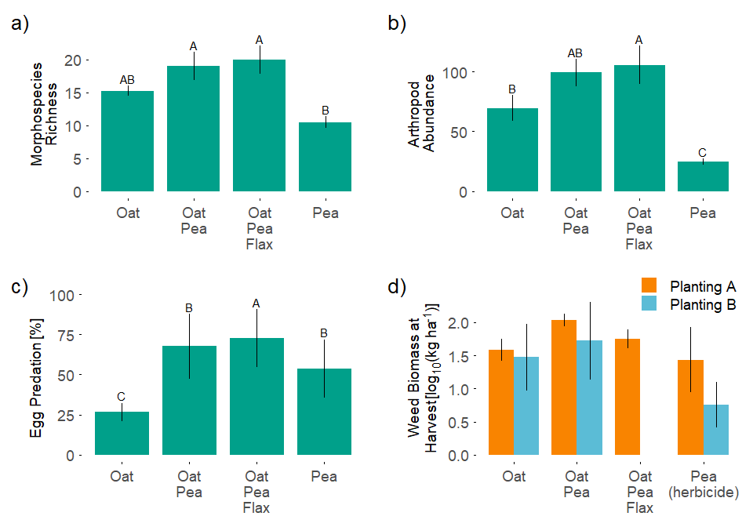

```r
xlabs = c('oat' = 'Oat',
          'oat-pea' = 'Oat\nPea',
          'oat-pea-flax' = 'Oat\nPea\nFlax',
          'pea' = 'Pea')
xlabs1 = c('oat' = 'Oat',
          'oat-pea' = 'Oat\nPea',
          'oat-pea-flax' = 'Oat\nPea\nFlax',
          'pea' = 'Pea\n(herbicide)')


p1 = richplt %>%
  text_sizer() +
  labs(tag='a)') +
  scale_x_discrete(labels=xlabs)
p2 = abundplt %>%
  text_sizer() +
  labs(tag='b)') +
  scale_x_discrete(labels=xlabs)
p3 = eggplt %>%
  text_sizer() +
  labs(tag='c)') +
  scale_x_discrete(labels=xlabs)
p4 = weedplt %>%
  text_sizer() +
  labs(tag='d)') +
  scale_x_discrete(labels=xlabs1) +
  theme(legend.position=c(0.8, 1),
        legend.key.size=unit(0.12, 'in'))

marrangeGrob(grobs=list(p1, p2, p3, p4),
             layout_matrix=matrix(c(1,2,3,4),
                                  nrow=2,
                                  byrow=TRUE),
             top=NULL)
```

```r
here('Results', 'Figure 5 - Services.jpeg') %>%
  jpeg(height=3.5, width=5, units='in', res=300)
marrangeGrob(grobs=list(p1, p2, p3, p4),
             layout_matrix=matrix(c(1,2,3,4),
                                  nrow=2,
                                  byrow=TRUE),
             top=NULL)
```

```r
dev.off()
```

# Anova table

```r
avt = anova_table

# format responses
is_predation = grepl('PREDATION', avt[, 'response'])
avt[is_predation, 'response'] = 'EGG_PREDATION'

is_weeds = grepl('WEED_BIOMASS', avt[, 'response'])
avt[is_weeds, 'response'] = 'WEED_BIOMASS'

is_biomass = grepl('COMBO_BIOMASS', avt[, 'response'])
avt[is_biomass, 'response'] = 'CROP_BIOMASS'

avt[, 'response'] = avt[, 'response'] |>
  gsub('COMBO_', '', x=_) |>
  gsub('_HAND', '', x=_) |>
  gsub('_MATURITY', '', x=_)


avt[, 'response'] = strsplit(avt[, 'response'], '_') |>
  sapply(function(x) {
    if (length(x) > 1 | (length(x) == 1 & nchar(x[1]) > 3)) {
      x = sapply(x, function(y) {
        first = substr(y, 1, 1)
        rest = substr(y, 2, nchar(y))
        paste0(first,
               tolower(rest))
      })
    }
    paste(x, collapse=' ')
  })

# format predictors
avt[, 'predictor'] = avt[, 'predictor'] |>
  strsplit(':') |>
  sapply(function(x) {
    x = sapply(x, function(y) {
        first = substr(y, 1, 1)
        rest = substr(y, 2, nchar(y))
        paste0(first,
               tolower(rest))
      })
    paste(x, collapse=" × ")
  })

facts = avt[!duplicated(avt[, 'predictor']), 'predictor']
avt[, 'predictor'] = factor(avt[, 'predictor'],
                            levels=facts)
```

```r
avt = pivot_longer(avt,
                   cols=where('is.numeric'))
avt = avt[avt$name=='p_val', ]
# avt[, 'value'] =
#   sapply(avt[['value']],
#          function(x) {
#            if (is.na(x)) {
#              x = ""
#            } else if (x < 0.001) {
#              x = "< 0.001"
#            } else {
#              x = round(x, 3) |>
#                as.character()
#            }
# })

avt = pivot_wider(avt, id_cols=c('response'),
              names_from='predictor',
              values_from='value')
```

```r
anova_gtab = gt(avt,
   rowname_col='response') |>
  sub_small_vals(threshold=0.001) |>
  fmt_number(decimals=3) |>
  tab_style_body(style=cell_text(weight='bold'),
                 fn=function(x) x < 0.05) |>
  sub_missing(missing_text='') |>
  tab_header(md("**Table 2**: *p*-values of treatment effects on measured variables")) |>
  opt_align_table_header(align='left') |>
  tab_footnote("Abbreviations: CP - Crude Protein; TDN - Total Digestible Nutrients; ADF - Acid Detergent Fiber; NDF - Neutral Detergent Fiber") |>
  cols_align('center')
anova_gtab
```

**Table 2**: *p*-values of treatment effects on measured variables

|  | Crop | Planting | Crop × Planting |
| --- | --- | --- | --- |
| Yield | <0.001 | 0.026 | 0.073 |
| Crop Biomass | <0.001 | 0.007 | 0.611 |
| LER |  | 0.203 |  |
| Oat Yield | <0.001 | 0.066 | 0.003 |
| Pea Yield | <0.001 | 0.020 | 0.002 |
| Ratio |  | 0.042 |  |
| CP | <0.001 | 0.036 | 0.001 |
| TDN | <0.001 | 0.724 | 0.279 |
| ADF | <0.001 | 0.688 | 0.236 |
| NDF | <0.001 | 0.821 | 0.150 |
| Egg Predation | <0.001 |  |  |
| Bugvac Richness | 0.004 |  |  |
| Bugvac Abundance | <0.001 |  |  |
| Weed Biomass | 0.092 | 0.427 | 0.607 |

Abbreviations: CP - Crude Protein; TDN - Total Digestible Nutrients; ADF - Acid Detergent Fiber; NDF - Neutral Detergent Fiber

```r
gtsave(anova_gtab,
       filename=here('Results', 'Table 2 - ANOVA.html'))
```